# PARCIALANALISISMATEMATICO-checkpoint-Copy1

DEFINICIÓN:

Coloquialmente, se dice que el límite de la función f(x) cuando x tiende a c es L , y se escribe:

${\displaystyle \lim _{x\to c}\,\,f(x)=L}\lim _{{x\to c}}\,\,f(x)=L$

si se puede encontrar para cada ocasión un x suficientemente cerca de c tal que el valor de f(x) sea tan próximo a L como se desee.

Para un mayor rigor matemático se utiliza la definición épsilon-delta de límite, que es más estricta y convierte al límite en una gran herramienta del análisis real. Su definición es la siguiente:

"El límite de f(x) cuando x tiende a c es igual a L si y sólo si para todo número real ε mayor que cero existe un número real δ mayor que cero tal que si la distancia entre x y c es menor que δ, entonces la distancia entre la imagen de x y L es menor que ε unidades".

Derivadas

1.- Indicar si c/u de las siguientes proposiciones es verdadera o falsa. Justificar toda respuesta, si es V demostrarla y si es Falsa dar un contraejemplo adecuado.

a) Toda función continua en un punto es derivable en ese punto.

b) Toda función derivable en un punto es continua en ese punto.

2.- Expresar el concepto de derivada de una función. Escribir la definición simbólicamente.

3.- Un heladero ha comprobado que, a un precio de 50 pesos la unidad, vende una media de 200 helados diarios. Por cada peso que aumenta el precio, vende dos helados menos al día. Si el coste por unidad es de 40 pesos, ¿a qué precio de venta es máximo el beneficio diario que obtiene el heladero? ¿Cual será ese beneficio? Resolver y dejar las fórmulas utilizadas.

RESPUESTAS DERIVADAS

Cito Pagina https://www.vadenumeros.es/segundo/continuidad-derivabilidad.htm#:~:text=Toda%20funci%C3%B3n%20f%20derivable%20en,la%20funci%C3%B3n%20en%20ese%20punto.

a. - Toda Función f derivable en un punto, con la derivada finita, es continua en ese punto en un punto.El recirpoco no es cierto, existe funciones continuas en un punto y no son derivables de él. FALSO

Derivadas laterales

Por la derecha: $ f'(x_0^+) = lim_{h \to 0^+}{ \frac{f(x_0+h)- f(x_0)}{h}} $

Por la izquierda: $ f'(x_0^-) = lim_{h \to 0^-}{ \frac{f(x_0+h)- f(x_0)}{h}} $

Si $ f'(x_0^+) = f'(x_0^-) $ la función es derivable en $ x_0 $

Si $ f'(x_0^+) \neq f'(x_0^-) $ la función no es derivable en $ x_0 $

b.- Toda Función derivable en un punto es continua en ese punto.

Toda función f derivable en un punto, con derivada finita, es continua en ese punto. Verdadero

Continuidad de la función en un punto $ x_0 $

1. Existe $ f(x_0) $

El punto debe pertenecer al dominio de la función

1. Existe el $ lim_{x \to x_0}{f(x)} $

En funciones definidas en partes, los límites laterales tienen que ser iguales

$ lim_{x \to x_0^-}{f(x)} = lim_{x \to x_0^+}{f(x)} $

1. $f(x_0) = lim_{x \to x_0}{f(x)} $

En funciones definidas en partes

$ lim_{x \to x_0^-}{f(x)} = lim_{x \to x_0^+}{f(x)} = lim_{x \to x_0}{f(x)} $

Si no se cumple alguna de estas condiciones la función es discontinua y no es derivable en $ x_0 $

2.- Expresar el concepto de derivada de una función. Escribir la definición simbólicamente.

Cito Pagina http://recursostic.educacion.es/descartes/web/materiales_didacticos/Derivada_de_una_funcion/Derivada_de_una_funcion.htm

La derivada es uno de los conceptos más importante en matemáticas. La derivada es el resultado de un límite y representa la pendiente de la recta tangente a la gráfica de la función en un punto. Pero vayamos por partes.

La definición de derivada es la siguiente: $$ f'(x) = lim_{h \to 0} \frac{f(x+h)-f(x)}{h} $$

3.- Un heladero ha comprobado que, a un precio de 50 pesos la unidad, vende una media de 200 helados diarios. Por cada peso que aumenta el precio, vende dos helados menos al día. Si el coste por unidad es de 40 pesos, ¿a qué precio de venta es máximo el beneficio diario que obtiene el heladero? ¿Cual será ese beneficio? Resolver y dejar las fórmulas utilizadas.

```python
import numpy as np


print("**********************************************")
print()
x=np.array([50,51,52,53,54,55])
x=np.array([x])
print ("Precio de Venta:", x)
print()
print("*********************************************")
print()
y=np.array([200,198,196,194,192,190])
print("Unidades Vendidas:",y)
print()
print("*********************************************")
```

[output not shown]

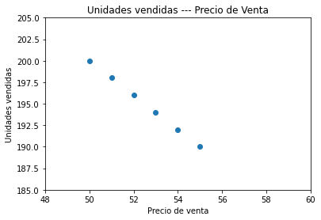

```python
import numpy as np #Librería numérica
import matplotlib.pyplot as plt # Para crear gráficos con matplotlib
#%matplotlib inline # Si quieres hacer estos gráficos dentro de un jupyter notebook

from sklearn.linear_model import LinearRegression #Regresión Lineal con scikit-learn


plt.title("Unidades vendidas --- Precio de Venta")
plt.scatter(x,y)
plt.xlabel("Precio de venta")

plt.ylabel("Unidades vendidas")
plt.axhline(5,color="black")
plt.axvline(5,color="black")
plt.xlim(48,60)
plt.ylim(185,205)
plt.show()
```

4.- Hay dos (2) tangentes a la curva $\hspace{1cm} y = 4x - x^2 \hspace{1cm}$ que pasan por el punto (2,5). Encuentre las ecuaciones de ambas. Sugerencia: Sea $(x_ 0, y_ 0) $ el punto de tangencia, encuentre las dos condiciones que debe satisfacer dicho punto.

```python
x=Symbol('x')
y=(-x**2+4*x)
sp.diff(y,x)
```

[output not shown]

Definimos $ m = -2x+4 $ que es la derivada de la parábola lo que nos dá la pendiente de la recta, la valuamos en un punto, ese punto es (x,y) o sea (2,5), por otro lado se calcula la pendiente de la recta que es tangente a ese punto $ m = \frac{y-y0}{x-x0} $ lo que nos queda $ m = \frac {5-y0}{2-x0} $ se igualan las pendientes para que queden en función de $ y0 $ y $ x0 $ .

$ -2x_0+4 = \frac {5-y_0}{2-x_0} $

$ -4x_0 + 2x_0^2 + 8 -4x_0 = 5 -y_0 $

$ y_0 = -2x_0^2 + 8x_0 -8 +5 $

Resolviendo els sistema de ecuaciones por igualdad

$ \left. \begin{array}\\ y_0 = -2x_0^2 + 8x_0 -3 \\ y_0 = -x_0^2 +4x_0 \\ \end{array} \right \} $

$ -2x_0^2 + 8x_0 -3 = -x_0^2+4x_0 $

$ -2x_0^2 + x_0^2 + 8x_0 -4x_0 -3 = 0 $

$ -x_0^2 +4x_0 -3 = 0 $

Resolviendo la ecuación cuadrática obtenemos las dos raíces $ x'_0 = 1 \, \, \, x_0 = 3 $ y evaluamos en la ecuación cuadratica y obtenemos el $ y_0 = -1^2 + 4·1 = 3 \, $ y $ \, y_0 = -3^2 + 4·3 = 3 $

El punto $ y_0 $ es uno solo porque es el punto de cada una de las ramas de la parábola.

Estos puntos son $ a(x'_0,y_0) $ y $ b(x_0,y_0) $ con ellos y la pendiente calculamos las ordenadas al origen de las rectas que pasan por el punto $ p(x,y) = (2,5) $

$ m_1= \frac {y-y_0}{x-x'_0} = \frac {5-3}{2-1} = 2 $

$ b_1=y-m_1·x = 5-2·2 = 1 $

$ y_1=2·x_1+1 $ e recta tangente a la parábola que pasa por el punto p(2,5)

$ m_2= \frac {y-y_0}{x-x_0} = \frac {5-3}{2-3} = -2 $

$ b_2=y-m_2·x = 5-(-2)·2 = 9 $

$ y_2=-2·x_2+9 $ Recta tangente a la parábola que pasa por el punto p(2,5)

```python
x=np.linspace(-10,10,100)
def y(x):
    return (-x**2+4*x)
def y1(x):
    return (2*x+1)
def y2(x):
    return (-2*x+9)
```

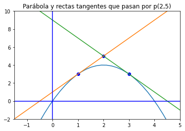

```python
plt.title("Parábola y rectas tangentes que pasan por p(2,5)")
plt.plot(x,[y(i) for i in x])
plt.plot(x,[y1(i) for i in x])
plt.plot(x,[y2(i) for i in x])
plt.axhline(0,color="blue")
plt.axvline(0,color="blue")
plt.xlim(-1.5,5.0)
plt.ylim(-2.0,10.0)
plt.scatter(2,5,color="blue")
plt.scatter(1,3,color="blue" )
plt.scatter(3,3,color="blue")
plt.show()
```

$ y_1=2·x_1+1 $

$ y_2=-2·x_2+9 $

5.- Resolver las siguientes Derivadas:

a) $ y= \frac{2}{x} - \frac{1}{x^2} $

b) $ y = (x^2 + 17)(x^3 - 3x + 1) $

c) $ f(x) = \left\{ \begin{array} \\ 2x^2 + 1 & \mbox{if } x \leq 1 \\ x + 2 & \mbox{if } x > 1 \end{array} \right. $

d) $ y = x^2 sen(x)$

Resolución Derivadas

a) $ y= \frac{2}{x} - \frac{1}{x^2} $